# MADS-DAV · Lesson 5 · Modelling relationships

## Seven of fifteen correlations change sign

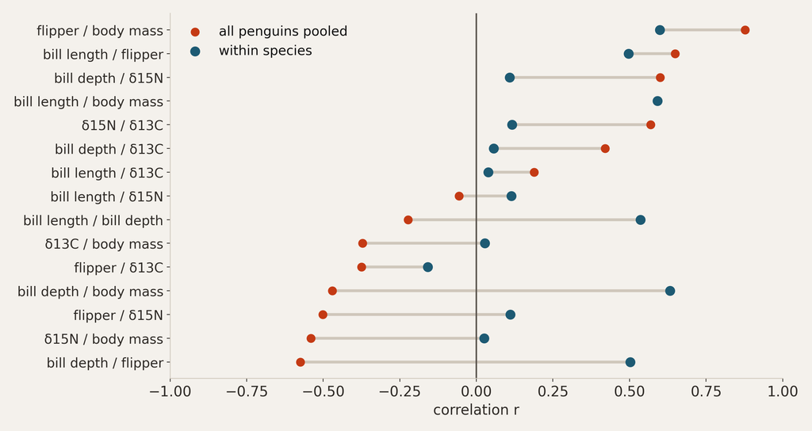

Red: all penguins together. Petrol: within species, after taking off each species’ own mean.

δ15N and body mass: −0.54 pooled, +0.03 within. The correlation was made entirely of species.

Bill length and body mass: +0.59 both ways. Bigger birds have bigger bills in every group. Not every correlation is fake.

Report per group, take the group mean off, or put the group in a model. But it has to be in your data.

5 / what can a correlation hide?

MADS-DAV · 42

All fifteen pairs, pooled and within species. Within species means: subtract each species' own mean from both columns, then correlate. That removes the differences between species and keeps the differences inside them. Seven of fifteen change sign. Two to point at. Nitrogen-15 and body mass: minus 0.54 pooled, a number you would report; within species 0.03, nothing. The correlation was not weakened by controlling for species, it was entirely made of species: delta 15N rises with what an animal eats, the species eat differently and happen to differ in size. Bill length and body mass: 0.59 pooled and 0.59 within: a bigger bird has a bigger bill, in every group. So the lesson is not 'distrust correlations'. Three ways to handle a confounder, in increasing effort: report per group, take the group mean off first, or put the variable in a model. And the part no method fixes: the confounder has to be in your data. If nobody had recorded the species, every number would be just as wrong, and nothing would tell you.

■ 5 — what can a correlation hide?

a linear regression with a penalty

## A penalty on the weights: what L1 and L2 do

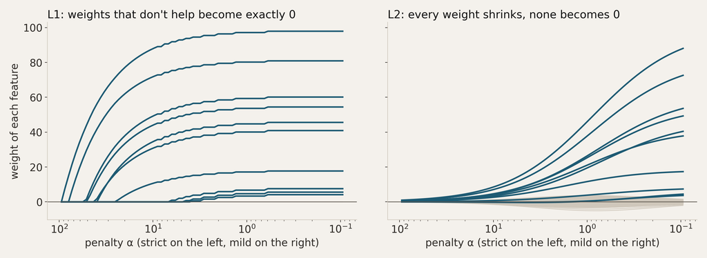

A linear regression gives every feature x a weight w, and picks the weights W with the smallest error:

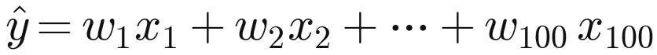

A penalty adds a cost for large weights to the error. α sets how strict:

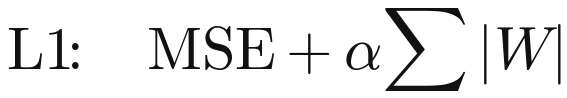

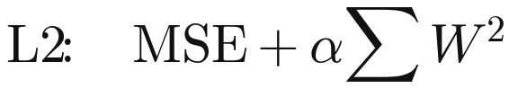

Left: L1 pushes weights that don’t help to exactly 0. Right: L2 shrinks every weight, but keeps them all. So L1 can select features. l1_ratio mixes the two; 1 is pure L1.

5 / what can a correlation hide?

MADS-DAV · 43

Before using it, what is a penalised regression? A linear regression gives every feature a weight and picks the weights that make the error smallest. With 100 features and 500 rows it will happily give every feature some weight, also the useless ones. A penalty adds a cost for large weights to the error. L1, also called lasso, adds alpha times the sum of the absolute weights; L2, ridge, adds alpha times the sum of the squared weights. Alpha sets how strict the penalty is; elastic net mixes the two, and its l1_ratio says how much is L1: 1 is pure L1, 0 is pure L2. The figure shows the weights of the same simulated data as the penalty goes from mild on the right to strict on the left. With L1 the weights of features that do not help are exactly zero, and as the penalty grows, the useful ones drop out one by one, the least useful first. With L2 every weight shrinks smoothly, and none ever becomes exactly zero. That is why L1 can be used to select features: what survives the penalty is what matters. The next slide uses that, which is a bit of a misuse: we do not want the regression as a model, we want its weights.

■ 5 — what can a correlation hide?

simulated · 500 rows · 100 features

## A penalty on the weights finds the useful features

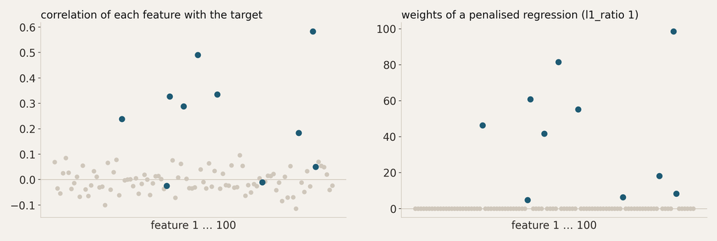

Right: the weights of a penalised regression. A grid search tried strictness and mix, and picked pure L1: l1_ratio = 1.

Petrol: the ten largest weights. Three of them have almost no correlation with the target. A grid search picked pure L1; the weights do the selecting.

5 / what can a correlation hide?

MADS-DAV · 44

● 05 — again, concretely

Pooled, longer bills are shallower. Within every species they are deeper. Same birds, opposite sentence.

Before you report a correlation, ask what else is different between the groups you compare.

The confounder has to be in your data. Species was, and one groupby fixed it. If nobody had recorded it, nothing would tell you.

With many features, let a penalised regression do the selecting, and read its weights.

45

Said again. In your own project the confounder will often be something you did not measure. The only defence is asking, out loud and before you write the sentence: what else is true of the groups I am comparing?

▲ question 06

can you recognise someone by how they type?

## A model that works can still be right for the wrong reason.

1 · Gate

Accuracy only tells you there is something to look at. It is not the finding.

2 · Read

The weights tell you what the model learned: a habit, or just a topic.

3 · Count

218,670 messages, but eight people. For a claim about people, n is eight.

46

Question six, notebook 05.5: one claim taken all the way through the grid. The claim: people are more identifiable by how they write than by what they write about. The mechanism is plausible and predicts something specific: habits should be stable while subjects drift. The data: the eight busiest people in #ubuntu-uk, action lines removed.

■ 6 — can you recognise someone by how they type?

8 people · one message at a time

## 47% right, but why?

A model reads one message and guesses who wrote it: 47% right, against 22% for always guessing the busiest person. A pass, so look at what it learned:

| person | words the model leans on | what that is |
| --- | --- | --- |
| ali1234 | n900, pidgin, qml, mythtv | subject matter |
| MartijnVdS | dimpy, mungbean, neuro | other people’s nicknames |
| zmoylan-pi | ireland, dublin | where he lives |
| daftykins | 0o, xd, hrmm | typing |
| popey | dont, didnt, thats | typing: no apostrophes |

Only the last two are how someone types. The rest is a topic detector, and it fails the moment someone changes the subject.

6 / can you recognise someone by how they type?

MADS-DAV · 47

Fit a model that reads one message and names its author: tf-idf over all words and a logistic regression. 47 percent right against a 22 percent baseline. Twice the baseline is a gate passed, not a destination: half the messages still go to the wrong person. The accuracy is the gate; what the model learned is the finding, and that is in the weights. Read the strongest words per person and they are not all the same kind of thing. ali1234: devices and software, subject matter. MartijnVdS: other people's nicknames, which is not a writing habit but a social position. zmoylan-pi: ireland, dublin, location. Only daftykins (0o, xd, hrmm) and popey (dont, didnt, thats: missing apostrophes) are about typing. The rest is a topic detector wearing a stylometry costume, and a topic detector fails as soon as someone changes subject, which is exactly the situation an authorship model is for. The habit worth stealing: when a model works, read its weights and ask what each one actually is.

■ 6 — can you recognise someone by how they type?

five regex steps and a groupby

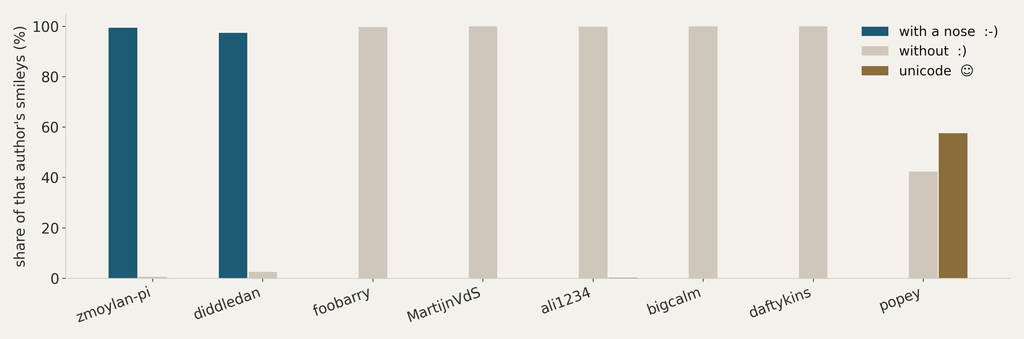

Measured directly with RegexFeature steps, no machine learning: smileys with a nose :-), without :), and the unicode ☺.

Not a matter of degree but a choice, made once and kept for years. Apostrophes, capitals and posting at night look the same.

6 / can you recognise someone by how they type?

MADS-DAV · 48

■ 6 — can you recognise someone by how they type?

4,368 blocks of 50 messages

## Fifty messages at a time: ten habits do what 17,918 words do

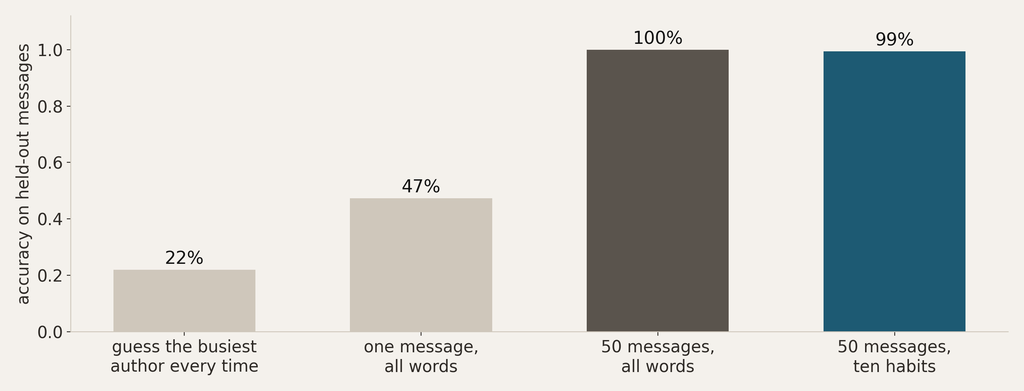

Three quarters of all messages carry no habit at all: “ok”, “thanks”, “brb”. One message usually gives the model nothing.

So pool 50 messages per person into a block. A model on all 17,918 words gets 100%; a model on ten habits gets 99%.

The ten-habit model knows no topics and no names. Identity is in how people type, and you can read its ten weights aloud.

6 / can you recognise someone by how they type?

MADS-DAV · 49

Why only 47 percent, when the habits look this decisive? The unit of analysis. 75 percent of messages contain neither a smiley nor a contraction: most lines are ok, thanks, brb. A model reading one line usually has nothing to go on; 47 percent is what a strong signal looks like when it is sparse. So stop asking about one message: pool fifty per person into a block, with a small TransformBase step of our own, BlockMessages, because what counts as one row is a decision worth naming. Then race two models on the same blocks: one that knows every word, 17,918 of them, and one that knows ten habits and nothing else. 100 against 99 percent. The one with no topics, no nicknames and no place names is within a point of the one that knows everything. That is the claim, demonstrated, with its caveat in the same sentence: it took volume to see. And ten weights can be read aloud: MartijnVdS is addressing people, daftykins is noseless smileys at night, foobarry is identified by never posting at night.

■ 6 — can you recognise someone by how they type?

2013–2014 against 2016–2017

## The same eight people, four years later

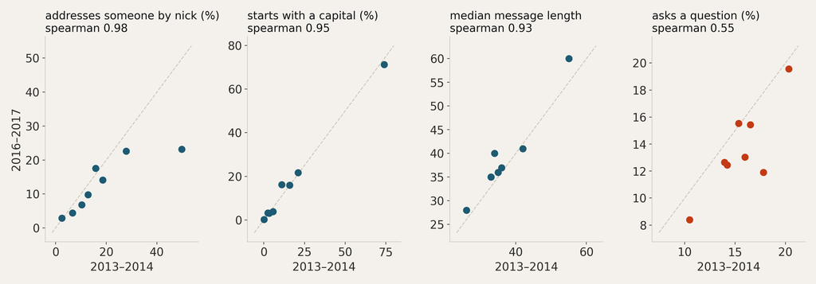

Each dot is one person: a habit in 2013–2014 against 2016–2017. On the diagonal means unchanged.

Addressing people, capitals, message length: the order of the eight hardly changes (spearman 0.93–0.98). That is replication.

Asking questions does move (0.55): it depends on whether you have a problem right now. A measure that could say no makes the others believable.

6 / can you recognise someone by how they type?

MADS-DAV · 50

● 06 — again, concretely

Ten habits recognise eight people, four years apart. But it is eight people.

The accuracy was a gate; the weights were the finding. Read them, and ask what each one really is.

218,670 messages don’t make n bigger. The claim is about people, so n = 8. Large data does not fix a small n.

Reported honestly: among the eight most active people, ten habits classify blocks of 50 messages at 99%, stable over four years. Others: untested.

51

Said again, and the objection the notebook saves for last. Through the grid this claim lands top left: a model that fits, a mechanism, replication. But there are eight people. The data is 218,670 messages and every test was at the person level for that reason, yet n is 8, and the claim is about people in general. A spearman of 0.98 across eight points is eight points. Large data does not fix a small n at the level of the claim: lesson 2's pseudoreplication, at the end of the notebook that was careful all along. The fix is cheap: the habits run on anyone with thirty messages, so recompute the stability over every person with enough history in both periods. The sentence at the bottom right is how it should be reported: n at the level of the claim, the effect, what was and was not tested, and no 'significant'.

What is a model?

A simplification you choose. Not true, not objective, useful for what it leaves out.

Why keep a model simple?

You can only understand simple shapes, and a model that fits anything tells you nothing.

How do you build a model?

Look, think, add one step or one term. Then read the residual.

When should you believe a pattern?

When it beats chance, has a mechanism, and shows up where you didn’t look.

What can a correlation hide?

The variable you left out. It has to be in your data.

Can you recognise someone by how they type?

These eight people, yes. Large data does not fix a small n.

Lesson 5 · Modelling relationships

52

The six questions from the start, with their answers. Notebooks 05.1 to 05.5 work through each of them: 05.1 the line as a claim, the hunt and the three legs; 05.2 correlation and Simpson's paradox; 05.3 the COVID model as a question you answer yourself, 05.4 the worked answer and the script; 05.5 how people type. In your own chat: pick a habit you can write as a regex, measure it per person, and report n at the level of your claim.

← → or click to move · F full screen · N speaker notes